# **Sosyal Medya ve Web Analizi**

Youtube Yorum Analizi

## 📌 **İçindekiler**

1. Ahmet Minguzzi Haber Analizi
2. Asgari Ücret Haber Analizi
3. İstanbul Depremi Haber Analizi
4. İklim Degisikligi Haber Analizi
5. Sonuç

# 1. Ahmet Minguzzi Haber Analizi

*“Haber Analizimizdeki amaç toplumun Ahmet Minguzzi olayı hakkında duygu ve düşüncelerini öğrenmek ve bu konu hakkındaki düşüncelerinden yola çıkarak verdikleri tepkiler sayesinde analizleri gerçekleştirmek.”*

##### Kelime Bulutu

Youtube üzerinden alınan yorumların kelime analizi sonuçlarında öncelikli olarak “Allah, ceza, adalet, anne, Ahmet, cani, idam, katil, eylesin” gibi sözcükler öne çıkmıştır. Bunun sonucunda bu olayın bir öldürülme vakası olduğunu ve toplumun bu konu hakkında aile yakınlarına baş sağlığı dilediğini ayrıca hukuki sürecin nasıl ilerlemesi gerektiğini belli etmiştir.

```
"Katil", "Caniler", "İdam", "Ceza", "Adalet" kelimeler ile adalet talebi oldukça yoğun. Kullanıcılar faile karşı ciddi bir öfke duyuyor ve ceza talebinde bulunuyorlar. "İdam" kelimesi sıklıkla geçmiş, bu da toplumsal öfkenin boyutunu gösteriyor.
```

[interactive chart not shown]

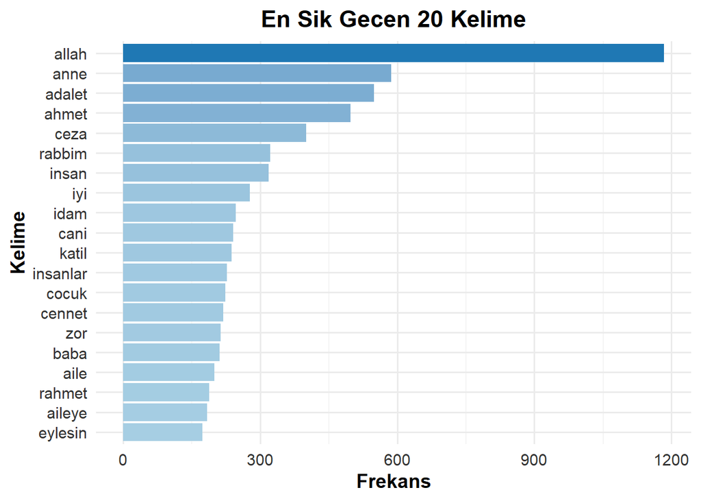

##### Emoji Analizi

Emoji Analizinde görüldüğü üzere kelime bulutunu destekleyen emojileri barındırıyor. Bu emojiler insanların üzgünlüğünü olayın duygusal boyutunu vurgulanmıştır. Özellikle 🥺 😭 🙏 ❤️ emojiler halkın tepki olarak üzüntülü, dua ve destek duygularını temsil ediyor. 😡 💔 😞 Öfke, kalp kırıklığı ve üzüntü içeren emojilerin sıklığı da dikkat çekmiştir. Bu da olayın sadece acı değil aynı zamanda öfke yarattığını da belirtiyor.

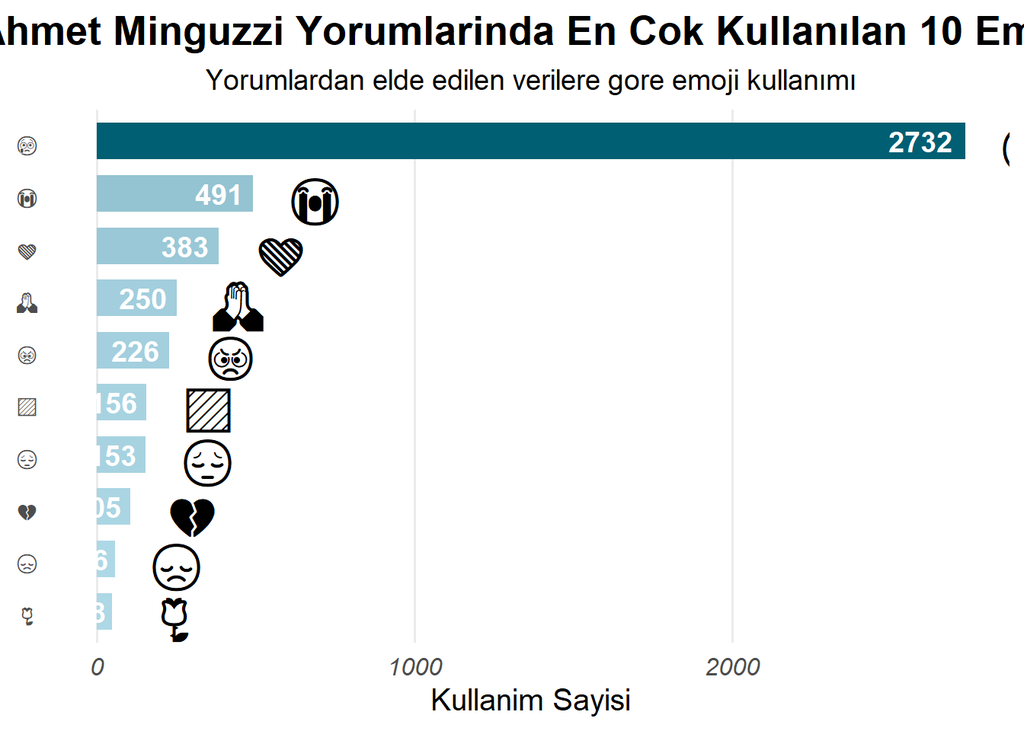

##### 2’li ve 3’lü Kelime Grupları

En sık kullanılan 2’li ve 3’lü kelime gruplarını incelediğimizde en çok “Allah Sabır, Rahmet Eylesin, Ağır ceza, çocuk değil, ağır ceza” kelimeleri 2li kelime gruplarında öne çıkarken 3’lü kelime gruplarında “Allah rahmet eylesin, sözün bittiği yer, ağır cezayı alsınlar, suça sürüklenen çocuk,” gibi cümleler cinayeti işleyenlerin en ağır cezayı almasını hatta bunu yapanların çocuk olduğunu anlamamıza yardımcı olmakta. Bu olayın toplumda büyük ses getirdiğini suçluların en ağır cezayı alması gerektiğini vurgulamış ayrıca ailesine sabırlar dilemeyi de unutmadıklarını söyleyebilirim.

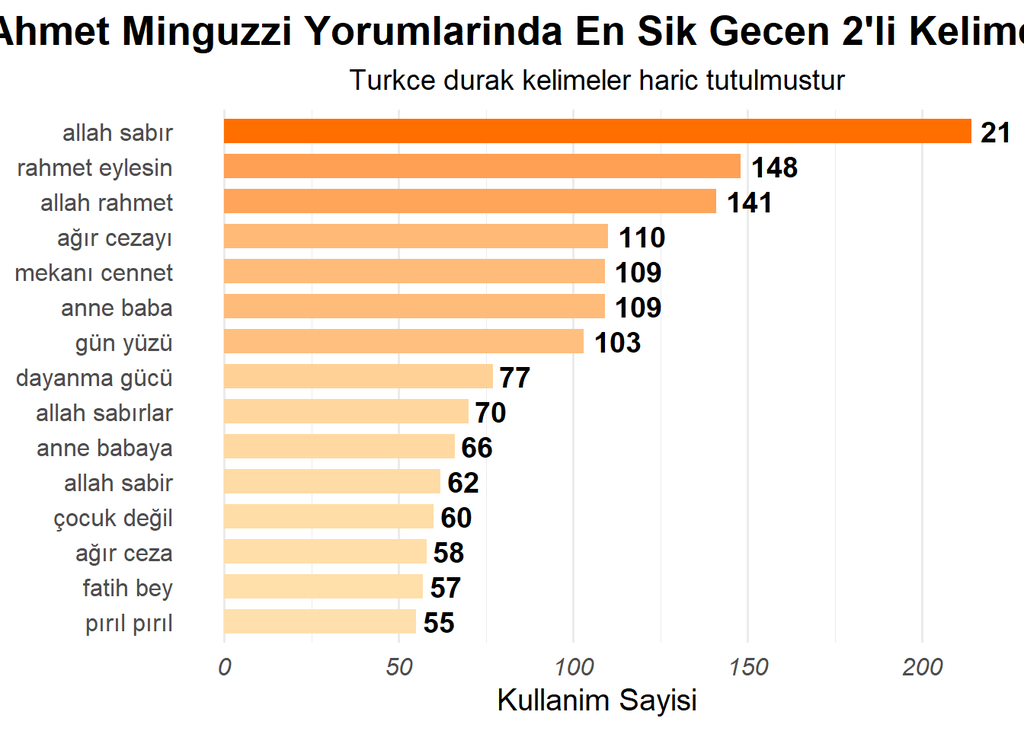

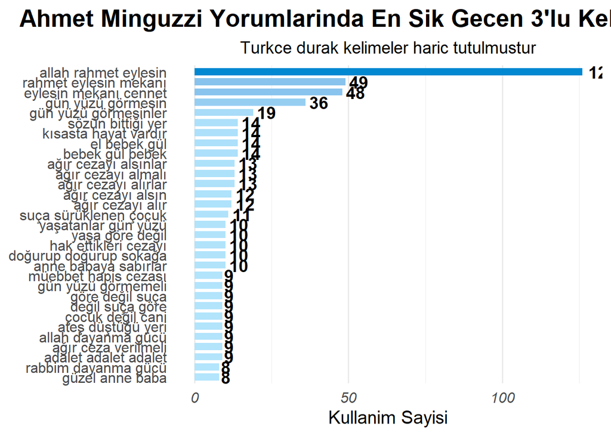

##### Kelime Ağı

Kelime ağında aslında diğer analizde olanlara rastladığımızı söyleyebilirim. Ama ayıran birkaç nokta var bunlardan biri “emsal karar” olarak bu cinayetin sonuca varmasını istediklerini, “tecrit edilmeli” diyerek cinayeti işleyenlerin toplumdan dışlanması gerektiğini söylemekte. Diğer bir dikkatimizi çeken “kufi kafada elleri” sözleri aslında bir şarkı sözü olduğunu ve toplumun bu şarkı ile “Ahmet” bağdaştırdığını söyleyebiliriz.

[interactive chart not shown]

##### Manuel Oluşturulan Duygu Analizi

Manuel olarak yapılan duygu analizinde Bert analizinde olduğu gibi burada da negatif duygular baskın çıkmıştır. Bunun sonucunda olayın toplumda negatif olarak değerlendirildiğini söyleyebiliriz.

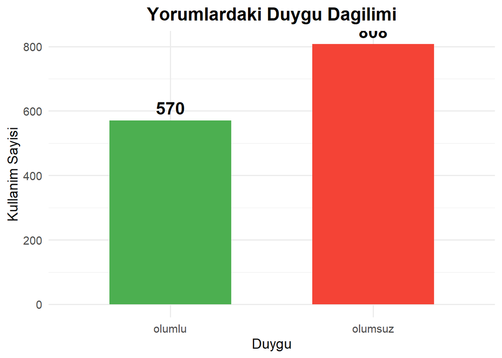

##### Bert İle Duygu Analizi

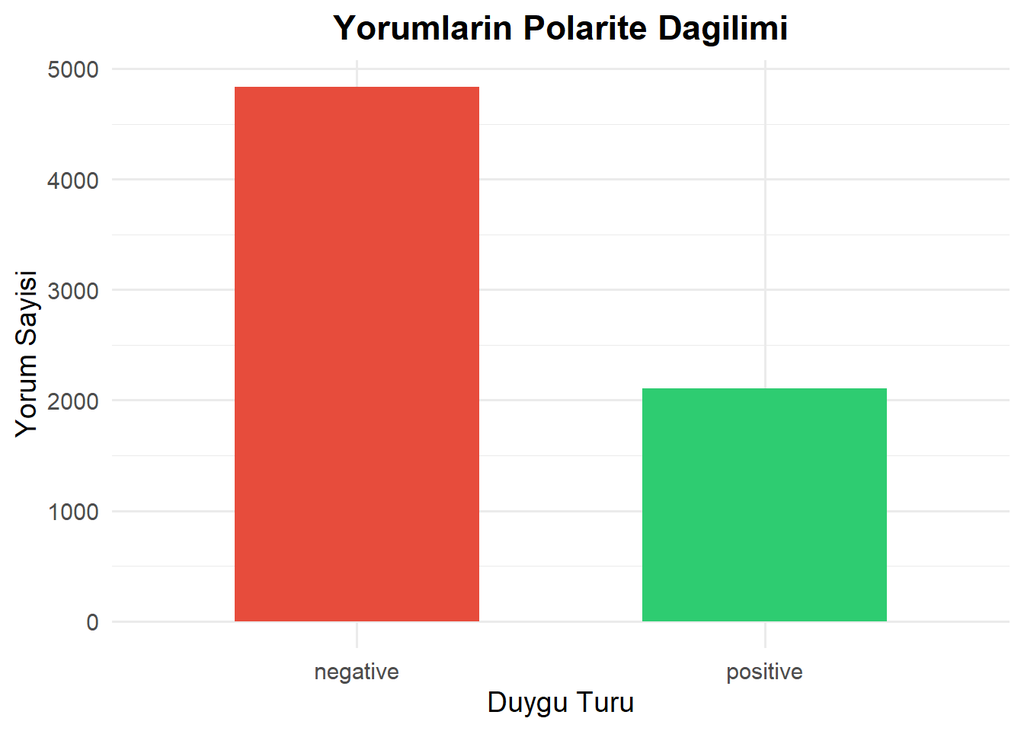

# 2. Asgari Ücret Haber Analizi

Asgari ücret analizinde toplumun değişen asgari ücret hakkındaki düşüncelerini içeren haber yorumlarından alınmıştır.

##### Kelime Bulutu

Kelime bulutundan elde edilen analiz ile öne çıkan kelimeler “asgari, zam, bin” kavramları konu ile alakalı olan öne çıkan kelimelerdir. Diğer kelimeler ise “emekli, millet, para, enflasyon, kira, zor” kelimeler öne çıkmıştır.

[interactive chart not shown]

##### Emoji Analizi

Emoji analizine baktığımızda kalp, kahkaha, üzgün, alkış, kızgın ifadelerin toplumun asgari ücret hakkında emoji analizinde net bir çıktı edemediğimi vurgulamak isterim.

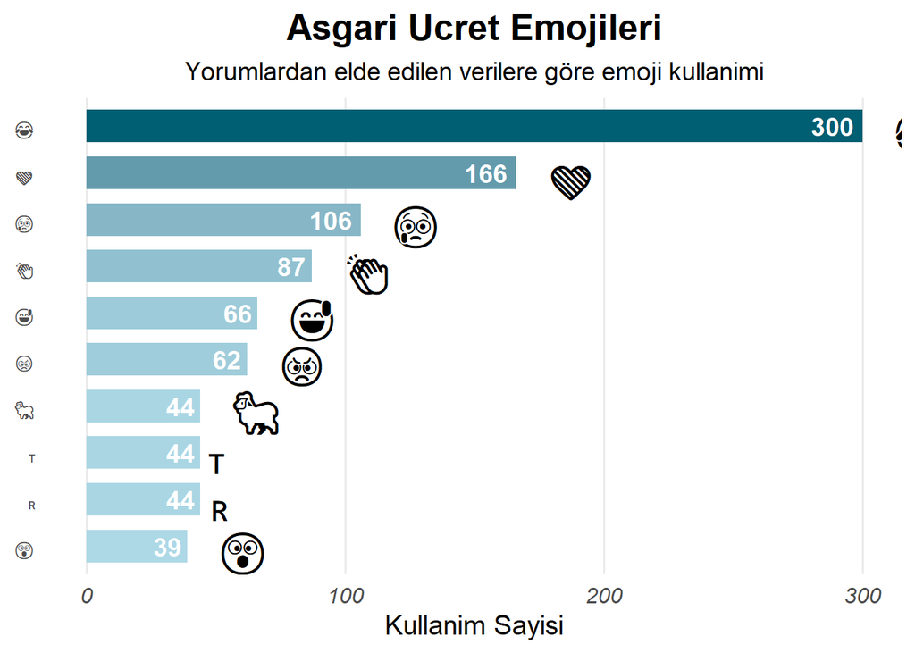

##### 2’li ve 3’lü Kelim Grupları

Kelime gruplarında ise “asgari ücret, erken seçim, düşük emekli maaşı” ve asgari ücret tahminleri barındıran bu kelime grupları bireylerin tahmini beklediğinin altında gerçekleştiğini söyleyebiliriz. Hatta asgari ücret konusu olan bu vidoların içinde emekliye de yer verilmesi emeklilerin kendi seslerini duyurmaya çalıştığını anlayabiliriz.

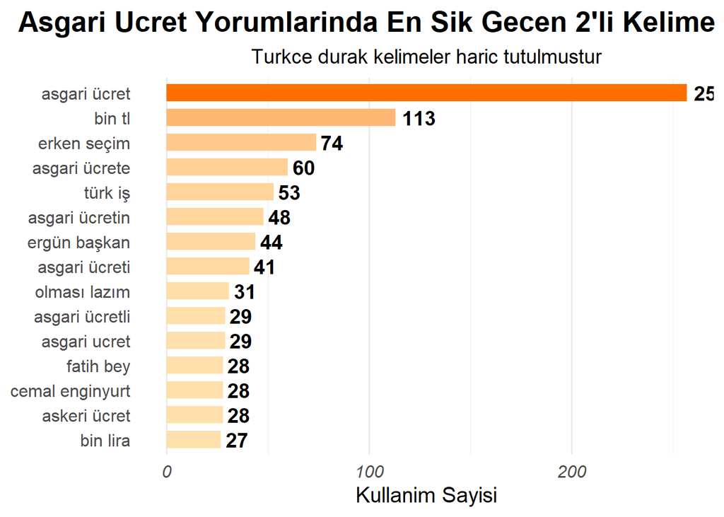

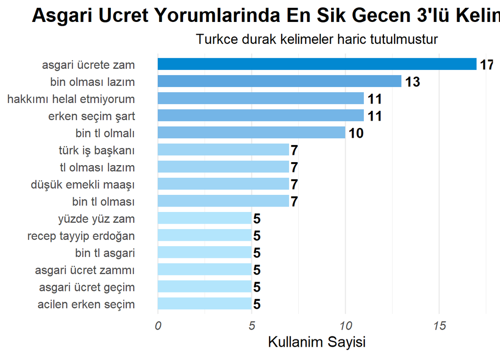

##### Kelime Ağı

Kelime Ağında ise “kira, elektrik, su, Pazar” kelimeleri asgari ücretin harcanacağı bireysel ihtiyaçları vurgulanmıştır. Bunlar dışında “memura zam” aslında memurların da kendilerine zam istediğini göstermektedir.

[interactive chart not shown]

##### Manuel Oluşturulan Duygu Analizi

Manuel duygu analizinde de negatif ağırlıklı yorumların bulunduğu söylenebilir. Bunlardan 360 negatif 55’i ise pozitif olduğunu söylemekte.

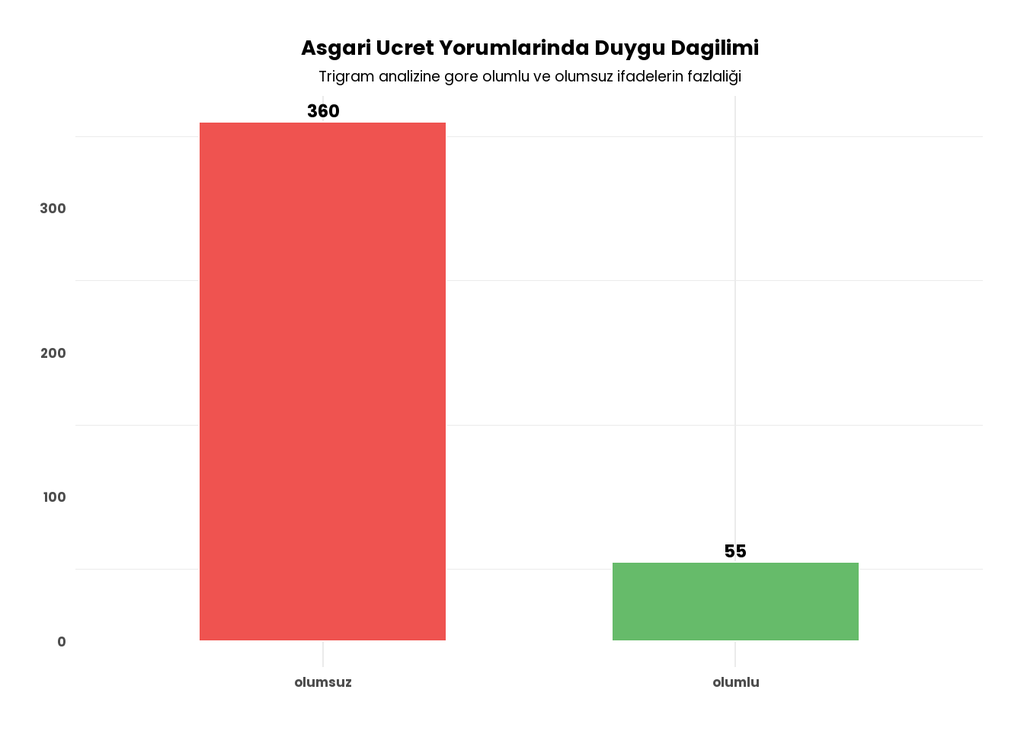

#####Bert İle Duygu analizi

Bert ile yapılan duygu analizinde 2654 negatif yorum bulunmaktadır. Ortalama ise -0.483 olduğunu bu da yorumların genel anlamda negatife kaydığını söyleyebiliriz.

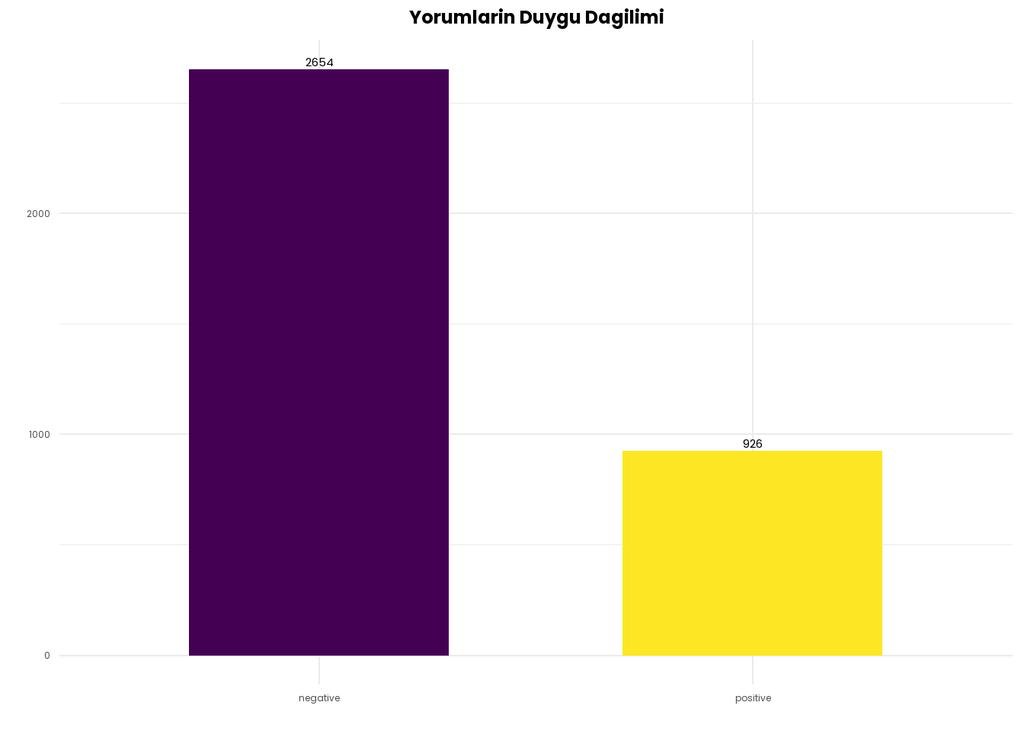

# 3. İstanbul Depremi Haber Analizi

Bu haber analizinde amaç toplumun deprem hakkındaki bilinç düzeyini yaşanılan depremdeki duygularını düşüncelerini öğrenerek olası bir depremde ne kadar hazır olduklarını öğrenmektir.

##### Kelime Bulutu

Kelime bulutunda elde edilenler “deprem, İstanbul, hoca, Celal, Fatih, kanal, bilim, bina, fay, panik” kavramları toplumun korktuğunu, endişe düzeyini hem de konunun sosyal, bilimsel ve duygusal boyutlarının bir arada ele alındığını gösterir.

[interactive chart not shown]

##### Emoji Analizi

Emoji analizinde kullanılan 🥺emojisi en sık kullanılan emoji olup toplumun yaşanan olay karşısında duyduğu endişe ve üzüntüyü güçlü biçimde yansıtır. ❤️emojisi ise toplumsal dayanışmayı, sevg, ve destek göstergesi olarak yaygın biçimde kullanılmıştır. 😂 kahkaha emojisi olan bu emoji muhtemelen ironik ve eleştirel tepkilerde yer almakta.

[figure not shown]

##### Kelime Grupları

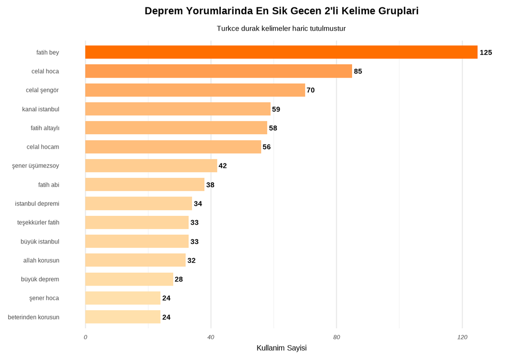

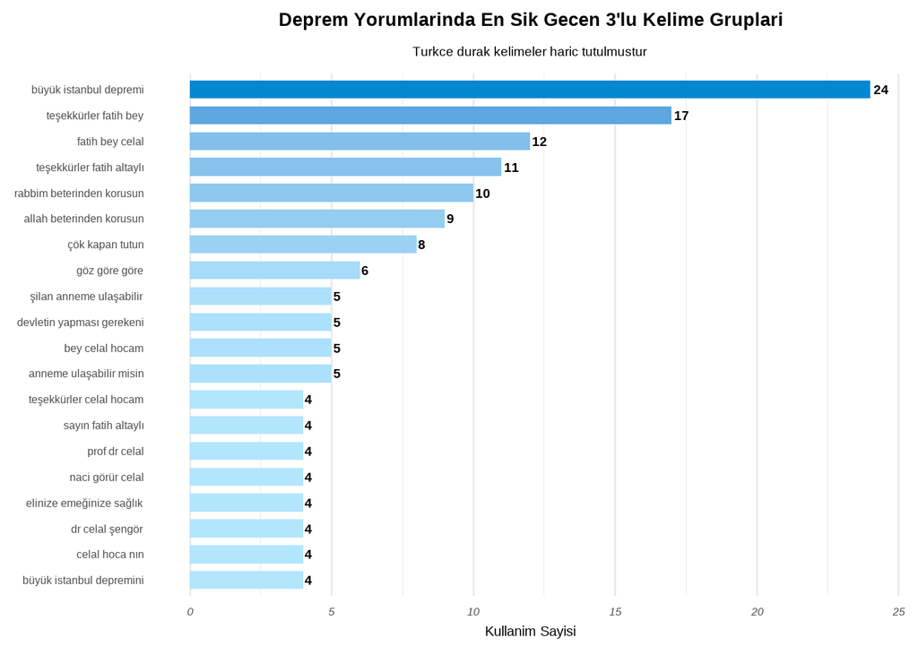

##### Kelime Ağı

Kelime Ağı analizinde “allah korusun, rabbim rahmet eylesin, rahmet Allah’tan olsun, herkesi muhafaza eylesin” gibi ifadeler, kullanıcıların duygularını ve dini temennilerini dile getirdiklerini göstermekte. Diğer bir kelime ağı “kanal İstanbul projesi”, “deprem riski taşıyor”, “fay hattı geçiyor”, “Ege denizi açıklarında”, “kuzey anadolu fay hattı” gibi yapılar, depremin coğrafi boyutunun halk tarafından tartışıldığını göstermiştir.

[interactive chart not shown]

##### Manuel Duygu Analizi

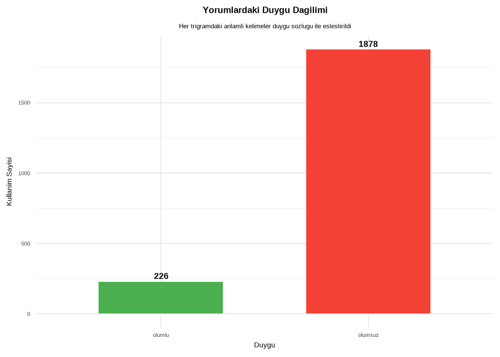

##### Bert ile Duygu Analizi Deprem hakkında yapılan Bert analizinde Negatif duygunun 2486 çıkarak ağırlıklı olduğunu görüldü. Ortalama duygu skorunun “-0.145” yani negatif çıkmıştır. Ama bu durum negatif bir duygu durumunu yansıttığını gösteriyor. Deprem gibi bir felaket durumun böyle sonuçlar beklenebilir çünkü insanlar genellikle endişe, üzüntü ve korku gibi olumsuz duyguları ifade eder. Standart sapma ve varyans baktığımızda nispete 1’e yakın çıkmıştır. Bu da yorumlar arasında belirgin duygu çeşitliliği olduğunu gösterir. Sebebi ise yardımlaşma veya dayanışma içeren yorumların pozitif duygular içermesi olabilir.

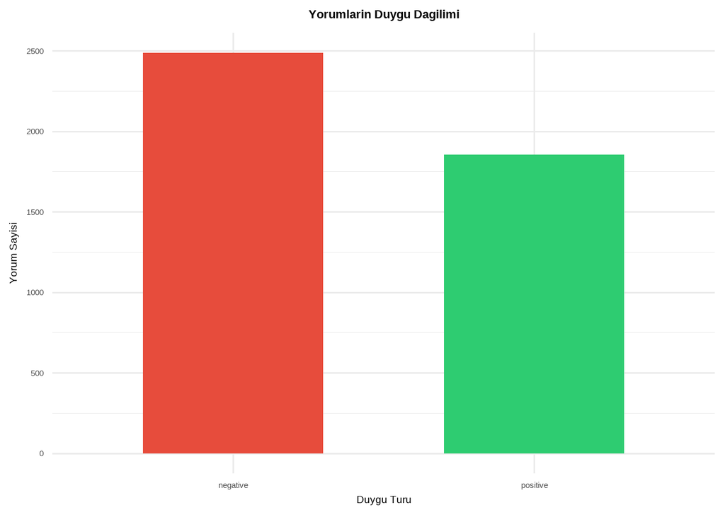

# 4. İklim Degisikligi Haber Analizi

##### Kelime Bulutu

İklim değişikliği hakkında yapılan yorumlarda kelime bulutuna yansıyanlardan bahsedecek olursam konu ile ilişkili olan “iklim, kozmik, karbon, manyetik, okyanuslar, radyasyon, atmosfer, su” kelimeleri öne çıkmakta bu da bireylerin bu konu hakkında bilgi sahibi olduğunu söylenebilir. Diğer göze çarpan kelimeler “kanun, insan, Allah, kabul” kelimeleri de diğer öne çıkan kelimelerdendir.

[interactive chart not shown]

##### Emoji Analizi

Emoji analizimizde “kalp, alkış, gülme, beğenme, dua, üzgün” öne çıkmakta bunların ise videoları beğendiklerini ayrıca konu hakkında endişeli oldukları söylenebilir.

[figure not shown]

##### 2’li ve 3’lü Kelime Grupları

En sık kullanılan kelime gruplarını 2’li olarak ele alındı. Bunu sonucunda toplumun iklim değişikliği hakkında yeterli bilgi ve tecrübeye sahip olduğunu hatta detaylı bir şekilde içerdiği konu başlıklarını kullandıklarını kelime gruplarında görmekteyiz. Örneğin kozmik radyasyon, aşırı enerji, iklim kanunu, güneş sistemi, karbon ayak izleri gibi sözcüklerle bu sonuca varılabilir.

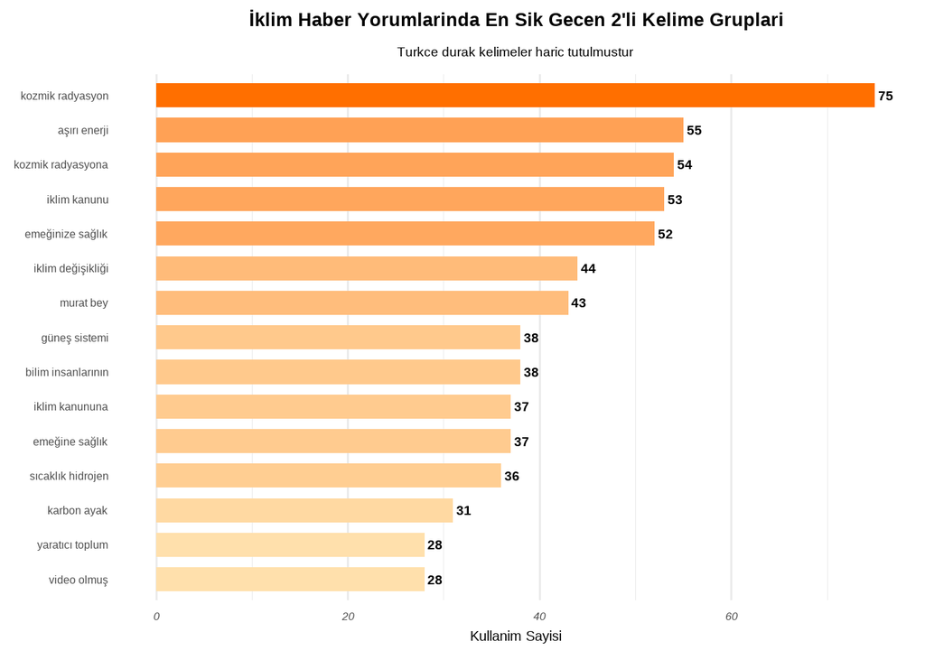

##### Kelime Ağı

[interactive chart not shown]

##### Manuel Duygu Analizi

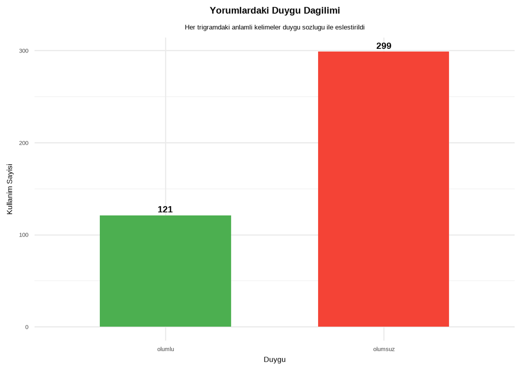

##### Bert ile Duygu Analizi

[figure not shown]

# 5. Sonuç

Sonuç olarak projemde asıl hedefimin toplum içerisinde berliediğim konu başlıklarına verdiği tepkileri “Youtube” üzerinden yorumlarına ulaşarak onları analiz etmektir. Her bir konuyu açıklayacak olursam Ahmet Minguzzi Olayı toplum içerisinde fazlasıyla tepkiyle karşılanan olay demek yanlış olmaz. Çünkü keskin cümleler ile idam istenmesi ayrıca aile olan baş sağlığı dilekleri durumun toplum tarafından üzücü karşılandığını bize açıkça belirtir.

İstanbul Deprem Haberleri toplumun bu konu hakkında bilinçli olduğunu ayrıca bireylerin bu konu hakkında hassas noktaları unutmadığını anlayabiliriz. Ayrıca yapılan analizler sonucunda toplumun büyük çoğunluğu bu konu hakkında korku ve endişe içerisinde olduğunu belirtebiliriz.

Asgari Ücret Haberleri elde edilen veriler sayesinde belirli kesimin asgari ücret konusunda mutlu olmadığını ve emekli kesimin de asgari ücreti artık ilgilendirdiğini söyleyebiliriz.

İklim Değişikliği Haberlerini analiz ederek elde ettiğim yorumlar ışığında toplumun belirli kesimin iklim değişikliği hakkında yeterli bilgiye sahip olduğunu söyleyebilirim. Öyle ki gerek kelime grupları gerek kelime bulutlarında bunu ispatlamıştır. Ama diğer çarpıcı bir konu toplumun iklim kanunu kabul olmasını isteyen ve istemeyen taraf olarak ikiye ayrıldığını söyleyebiliriz.

```
Yapmış olduğum proje kapsamında toplumun haberlere karşı tepkilerini ölçerek tek bir platform üzerinden analizler ile çıktı sağlamayı amaçladım.
```